# The Blue Zones: Why do some areas of the world have higher life expectancies than others?

#linear model on year 2000

```r
lm3 <- lm(life_expectancy ~ bmi + polio + percentage_expenditure + hepatitis_b +measles +total_expenditure + diphtheria + hiv_aids + gdp + income_composition_of_resources + schooling+ alcohol,lc_2000)

summary(lm3)
```

```
##
## Call:
## lm(formula = life_expectancy ~ bmi + polio + percentage_expenditure +
##     hepatitis_b + measles + total_expenditure + diphtheria +
##     hiv_aids + gdp + income_composition_of_resources + schooling +
##     alcohol, data = lc_2000)
##
## Residuals:
##    Min     1Q Median     3Q    Max
## -8.558 -1.858  0.108  2.061  5.056
##
## Coefficients:
##                                  Estimate Std. Error t value Pr(>|t|)
## (Intercept)                      5.10e+01   3.26e+00   15.64  < 2e-16 ***
## bmi                              5.15e-02   2.69e-02    1.91  0.06171 .
## polio                           -1.77e-02   2.86e-02   -0.62  0.53937
## percentage_expenditure          -1.66e-03   1.87e-03   -0.89  0.37937
## hepatitis_b                      2.92e-02   1.71e-02    1.71  0.09378 .
## measles                          9.95e-05   5.28e-05    1.88  0.06558 .
## total_expenditure               -2.04e-02   2.26e-01   -0.09  0.92821
## diphtheria                       2.22e-02   2.04e-02    1.09  0.28265
## hiv_aids                        -5.03e-01   4.66e-02  -10.80  1.9e-14 ***
## gdp                              3.59e-04   3.13e-04    1.15  0.25764
## income_composition_of_resources  2.37e+00   2.55e+00    0.93  0.35644
## schooling                        1.12e+00   2.75e-01    4.06  0.00018 ***
## alcohol                          1.01e-01   1.78e-01    0.57  0.57254
## ---
## Signif. codes:  0 '***' 0.001 '**' 0.01 '*' 0.05 '.' 0.1 ' ' 1
##
## Residual standard error: 3.28 on 48 degrees of freedom
## Multiple R-squared:  0.846,  Adjusted R-squared:  0.807
## F-statistic: 21.9 on 12 and 48 DF,  p-value: 1.78e-15
```

```r
lm_new3=lm(life_expectancy ~ hepatitis_b + hiv_aids +schooling +income_composition_of_resources ,lc_2000)

summary(lm_new3)
```

```
##
## Call:
## lm(formula = life_expectancy ~ hepatitis_b + hiv_aids + schooling +
##     income_composition_of_resources, data = lc_2000)
##
## Residuals:
##    Min     1Q Median     3Q    Max
## -8.505 -2.392  0.099  2.992  5.903
##
## Coefficients:
##                                 Estimate Std. Error t value Pr(>|t|)
## (Intercept)                      52.4704     2.4574   21.35  < 2e-16 ***
## hepatitis_b                       0.0163     0.0151    1.08    0.284
## hiv_aids                         -0.5197     0.0463  -11.23  5.7e-16 ***
## schooling                         1.2966     0.2135    6.07  1.2e-07 ***
## income_composition_of_resources   3.9731     2.3247    1.71    0.093 .
## ---
## Signif. codes:  0 '***' 0.001 '**' 0.01 '*' 0.05 '.' 0.1 ' ' 1
##
## Residual standard error: 3.41 on 56 degrees of freedom
## Multiple R-squared:  0.806,  Adjusted R-squared:  0.792
## F-statistic: 58.2 on 4 and 56 DF,  p-value: <2e-16
```

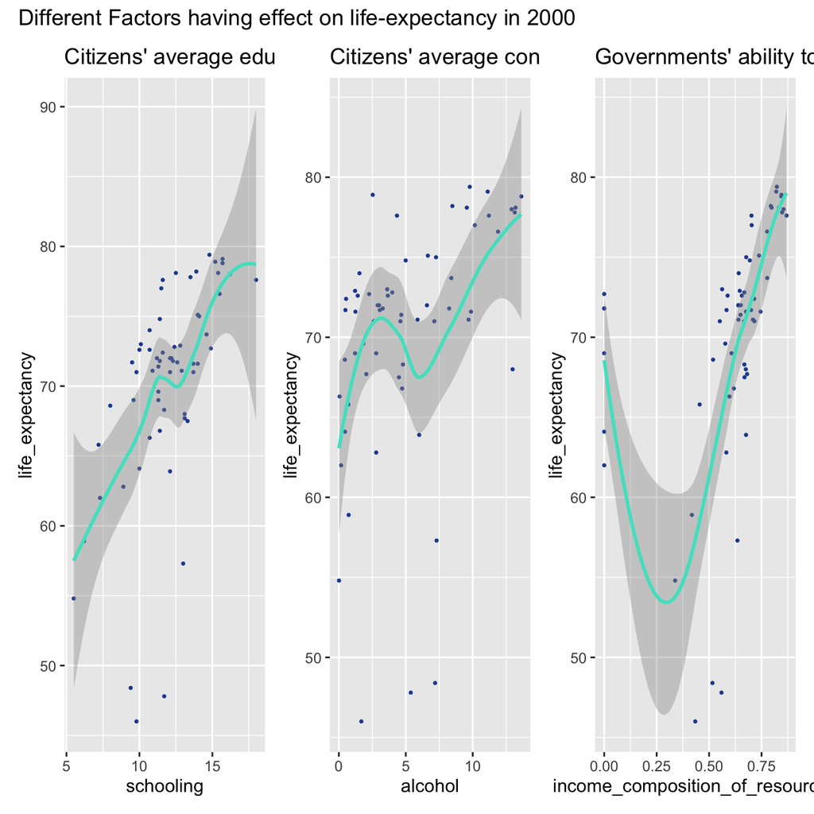

```r
a<-ggplot(lc_2000, aes(x = schooling, y = life_expectancy))+
  geom_point(colour="#234BA0",size=0.5)+
  geom_smooth(colour="#4FE1C8")+
  labs(title="Citizens' average education level (+)")


b<-ggplot(lc_2000, aes(x =alcohol, y = life_expectancy))+
  geom_point(colour="#234BA0",size=0.5)+
  geom_smooth(colour="#4FE1C8")+
  labs(title="Citizens' average consumption of alcohol (+)")


c<-ggplot(lc_2000, aes(x =income_composition_of_resources, y = life_expectancy))+
  geom_point(colour="#234BA0",size=0.5)+
  geom_smooth(colour="#4FE1C8")+
  labs(title="Governments' ability to utilize resources (+)")

a+b+c + plot_annotation(
  title = "Different Factors having effect on life-expectancy in 2000"
)
```

## 0.5 Further Visualization

Before doing the actual analytics, we assumed that GDP would be correlated with life-expectancy, but the linear regression result suggested otherwise. Therefore, we did further clustering analysis on GDP and life-expectancy and tried to identify the reasons behind why GDP and life-expectancy is not linearly correlated.

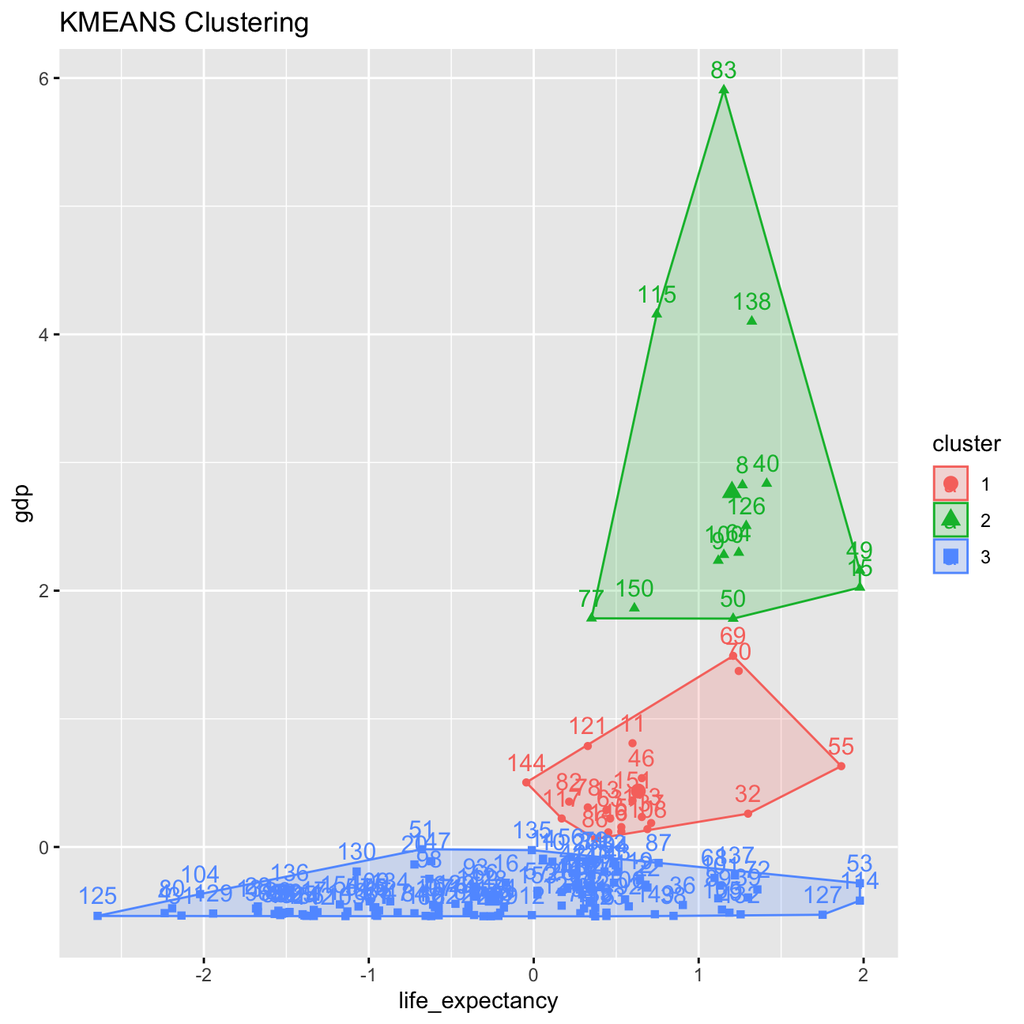

```r
library(factoextra)

lifeExp_factors <- read_csv(file = "data viz dataset/CLEANED-Life Expectancy - potential factors.csv",show_col_types = FALSE)

lifeExp_factors_cluster <- lifeExp_factors %>%
  clean_names() %>%
  filter(year==2014) %>%
  select("life_expectancy", "gdp") %>%
  na.omit()

# lifeExp_factors %>%
#   clean_names() %>%
#   filter(year==2014) %>%
#   select("country", "life_expectancy", "gdp") %>%
#   slice_max(gdp, n=10) %>%
#   arrange(desc(gdp))
#
# lifeExp_factors %>%
#   clean_names() %>%
#   filter(year==2014) %>%
#   select("country", "life_expectancy", "gdp") %>%
#   slice_max(life_expectancy, n=10) %>%
#   arrange(desc(life_expectancy))

model_kmeans <- eclust(lifeExp_factors_cluster, "kmeans", k=3, graph = TRUE)
```

```r
#Let's check the components of this object.
summary(model_kmeans)
```

```
##              Length Class  Mode
## cluster      155    -none- numeric
## centers        6    -none- numeric
## totss          1    -none- numeric
## withinss       3    -none- numeric
## tot.withinss   1    -none- numeric
## betweenss      1    -none- numeric
## size           3    -none- numeric
## iter           1    -none- numeric
## ifault         1    -none- numeric
## clust_plot     9    gg     list
## silinfo        3    -none- list
## nbclust        1    -none- numeric
## data           2    tbl_df list
```

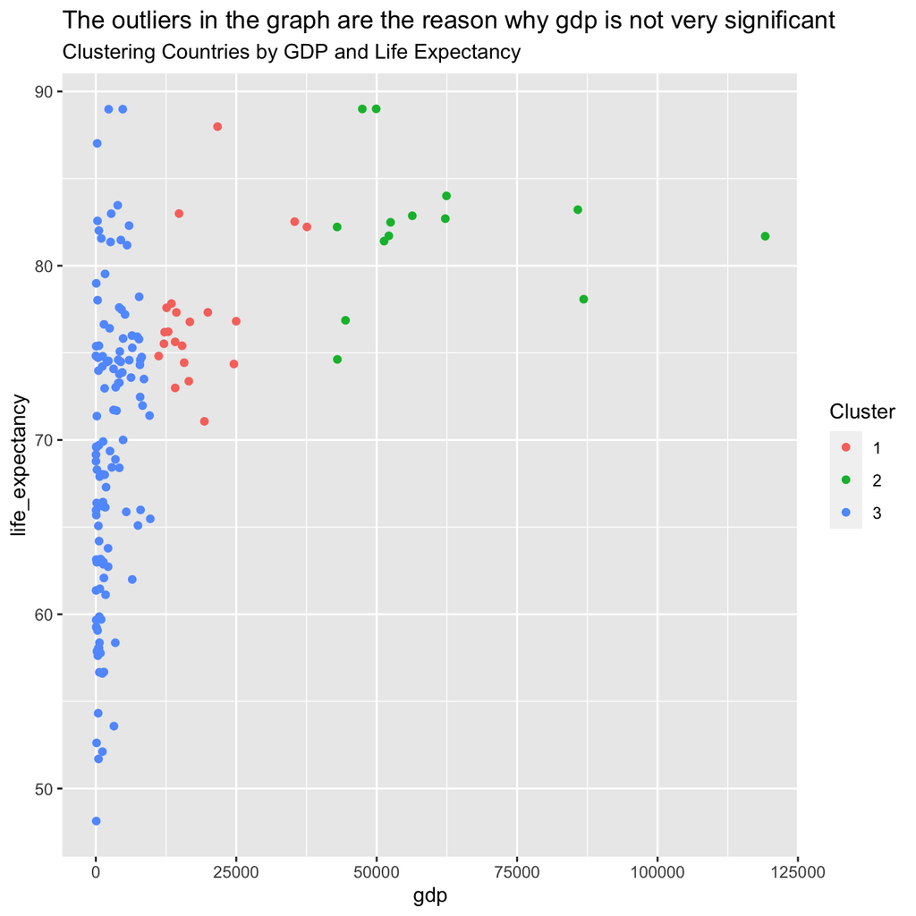

```r
library(ggpubr)

lifeExp_factors_withClusters<-mutate(lifeExp_factors_cluster, cluster = as.factor(model_kmeans$cluster))

ggplot(lifeExp_factors_withClusters, aes(x = gdp, y = life_expectancy, color =  as.factor(cluster))) +
  geom_jitter()+
  labs(color = "Cluster",
       title = "The outliers in the graph are the reason why gdp is not very significant",
       subtitle = "Clustering Countries by GDP and Life Expectancy")
```

Using kmeans method, we can tell that there are three groups of countries: a) countries with low gdp and lower life expectancy; b) countries with median gdp and higher life expectancy; c) countries with high gdp and high life expectancy. However, there are outliers in the (a) group. Citizens in some countries have high life expectancy despite low gdp. After examining these countries, we found that they are exercising a healthier life style. Maybe that’s the reason why gdp is not significant in the regression models.

> 5. Discussion and critique. What did you learn about the process of carrying out your project? What went wrong, and how could you improve it next time? For instance, did any sources of bias creep into your survey or experiment? What advice would you give future students?

(2)For features like “infant mortality”, and “under-five deaths”, even if they are significantly related to the dependent variable, it cannot generate any useful explanatory result. There fore we should focus on variables that could potentially be well explained.

For future references, we should be more careful when dealing with feature choice and feature engineering, especially focus on variable’s explaining power and multi-colinearity problem.